# Firearm Discounting Methods

# Methodology

## Rationale

The primary goal here is to concurrently evaluate how delay discounting phenomena (i.e., temporally-extended events) can interact with more traditional metrics representing outcomes (i.e., efficacy).

In this demonstration, two factors of interest are evaluated with respect to individual decision-making. The first factor speaks to how the magnitude between immediate/delayed prospects factor into individual choice. For example, some may be particularly sensitive to delayed prospects with greater magnitdues (irrespective of the delay). Alternatively, the second factor speaks to sensitivity to delays. For instance, some may be particularly sensitive to differences in delay and may disregard prospects with higher utility in the future.

## Modeling

### Logistic Modeling

In contrast to titration procedures, the methods provided here apply a multi-level logistic approach. Such an approach circuments the unnecessary compression of individual variance (i.e., individual-means), avoids a two-stage analysis, and altogether improves analytical power.

Specific model structure is provided below:

$$P(Waiting) = logistic(\beta_{Magnitude} * ln(\frac{LL_{Magnitude}}{SS_{Magnitude}})+\beta_{Delay} * ln(LL_{Delay} + 1))$$

### Multilevel Modeling

In addition to the benefits of logistic modeling noted above, this approach is easily expanded to a multi-level approach. The benefits of this approach are numerous and the reader is directed to Young (2017) for a review of the merits of this approach in delay discounting experiments.

The specific model and structure used in this study is indicated below:

$$Waited ~ Group*LogMagnitudeRatio + Group*logDelayRatio - 1 - Group + (LogMagnitudeRatio + LogDelayRatio - 1 | Subject)$$

In this formulation, intercepts are not permitted to vary but individual sopes (i.e., simple slopes) are allowed to vary at the individual level for both Delay and Magnitude ratios.

## Hypothetical Usage in Suicidology

In this study, data are simulated based on two hypothetical groups.

Per this simulation, an aggregate description is provided below across groups (and delay points):

| Group | LLdel | AverageProbabilityOfWaiting | SdProbabilityOfWaiting |
| --- | --- | --- | --- |
| 0 | 1 | 0.615 | 0.4878164 |
| 0 | 2 | 0.465 | 0.5000251 |
| 0 | 4 | 0.300 | 0.4594075 |
| 0 | 8 | 0.175 | 0.3809206 |
| 0 | 16 | 0.065 | 0.2471445 |
| 1 | 1 | 0.660 | 0.4748975 |
| 1 | 2 | 0.670 | 0.4713927 |
| 1 | 4 | 0.555 | 0.4982129 |
| 1 | 8 | 0.520 | 0.5008535 |
| 1 | 16 | 0.390 | 0.4889739 |

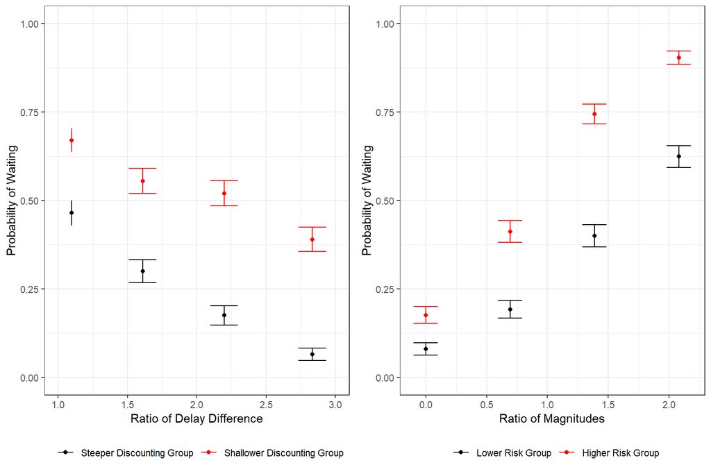

Simulated data were compared using the methods listed above. Across all individuals, weights were fitted for the logMagnitudeRatio and logDelayRatio. Groupings were dummycoded such that interactions between the factors listed above clearly illustrate the magniude of differences associated between groups. As noted above, individual slopes varied across factors but not intercepts.

```
## Generalized linear mixed model fit by maximum likelihood (Laplace
##   Approximation) [glmerMod]
##  Family: binomial  ( logit )
## Formula:
## Waited ~ Group * logMagRatio + Group * log(LLdel + 1) - 1 - Group +
##     (logMagRatio + log(LLdel + 1) - 1 | Subject)
##    Data: finalDataFrame
##
##      AIC      BIC   logLik deviance df.resid
##   1773.8   1813.0   -879.9   1759.8     1993
##
## Scaled residuals:
##     Min      1Q  Median      3Q     Max
## -5.5434 -0.5031 -0.1218  0.4912  8.3252
##
## Random effects:
##  Groups  Name           Variance Std.Dev. Corr
##  Subject logMagRatio    0.062687 0.25037
##          log(LLdel + 1) 0.007531 0.08678  -1.00
## Number of obs: 2000, groups:  Subject, 100
##
## Fixed effects:
##                      Estimate Std. Error z value Pr(>|z|)
## logMagRatio           1.92877    0.14300  13.488  < 2e-16 ***
## log(LLdel + 1)       -1.95685    0.12382 -15.804  < 2e-16 ***
## Group:logMagRatio     0.05199    0.18828   0.276    0.782
## Group:log(LLdel + 1)  0.99165    0.14326   6.922 4.45e-12 ***
## ---
## Signif. codes:  0 '***' 0.001 '**' 0.01 '*' 0.05 '.' 0.1 ' ' 1
##
## Correlation of Fixed Effects:
##             lgMgRt l(LL+1 Grp:MR
## log(LLdl+1) -0.885
## Grop:lgMgRt -0.714  0.633
## Grp:l(LL+1)  0.740 -0.843 -0.839
## convergence code: 0
## boundary (singular) fit: see ?isSingular
```

```
##  Group logMagRatio.trend    SE  df asymp.LCL asymp.UCL
##      0              1.93 0.143 Inf      1.65      2.21
##      1              1.98 0.132 Inf      1.72      2.24
##
## Trends are based on the logit (transformed) scale
## Confidence level used: 0.95
```

```
##  Group LLdel.trend     SE  df asymp.LCL asymp.UCL
##      0      -0.269 0.0170 Inf    -0.302    -0.236
##      1      -0.133 0.0106 Inf    -0.153    -0.112
##
## Trends are based on the logit (transformed) scale
## Confidence level used: 0.95
```

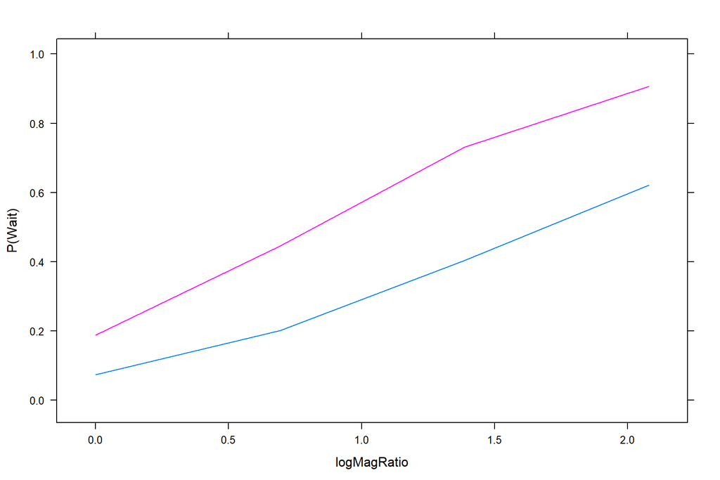

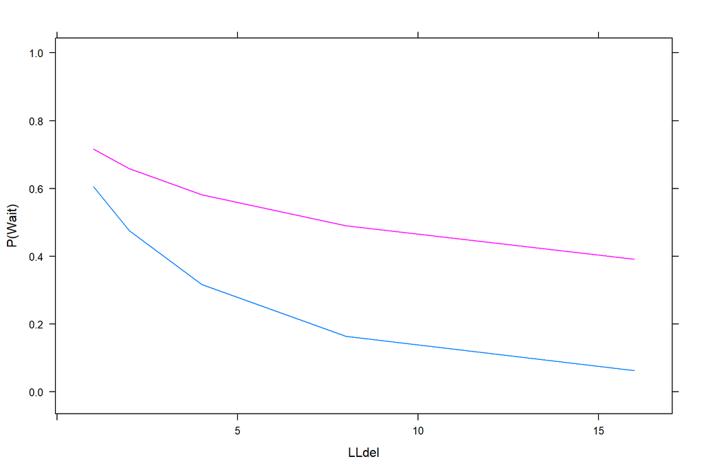

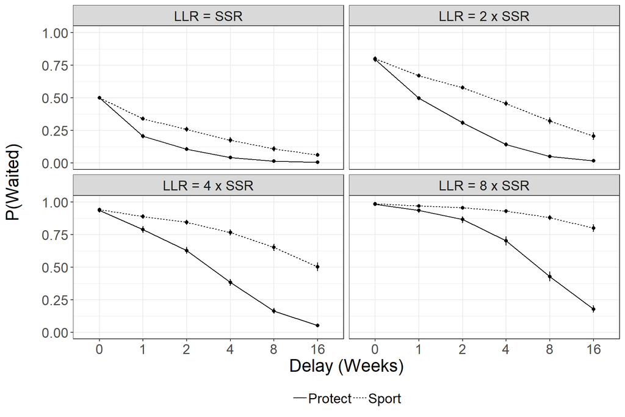

Here we see that our fixed effects for group closely map to our seed values for Group 1. For Group 2, we calculated each using these fitted values.

```r
### Group 1 logMagRatio
fixef(simulatedComparison)["logMagRatio"]
```

```
## logMagRatio
##    1.928765
```

```r
### Group 2 logMagRatio
fixef(simulatedComparison)["logMagRatio"] + fixef(simulatedComparison)["Group:logMagRatio"]
```

```
## logMagRatio
##    1.980757
```

```r
### Group 1 logDelRatio
fixef(simulatedComparison)["log(LLdel + 1)"]
```

```
## log(LLdel + 1)
##       -1.95685
```

```r
### Group 2 logDelRatio
fixef(simulatedComparison)["log(LLdel + 1)"] + fixef(simulatedComparison)["Group:log(LLdel + 1)"]
```

```
## log(LLdel + 1)
##     -0.9651954
```